# Data

## What is National Syndromic Surveillance Program (NSSP) data?

National Syndromic Surveillance Program (NSSP) data are collected by the U.S. Centers for Disease Control and Prevention, in collaboration with local and state health departments and private sector partners. NSSP data include surveillance data tracking the percentage of emergency department (ED) visits due to influenza-like illness, including influenza, COVID-19, and RSV. NSSP data reporting of ED visits due to influenza-like illness began in late 2022. Data are available on a weekly time scale, with data from the prior week added Friday mornings.

## What sub-state-level data are available?

At the sub-state level, reporting facilities can be aggregated to the level of health service area (HSA). HSAs are single- or multi-county clusters that correspond with healthcare-seeking patterns. All publicly-available county-level NSSP data are really HSA values, such that each county in the HSA will have the same value as the parent HSA.

A list of HSAs can be downloaded [here](https://view.officeapps.live.com/op/view.aspx?src=https%3A%2F%2Fseer.cancer.gov%2Fseerstat%2Fvariables%2Fcountyattribs%2FHealth.Service.Areas.xls&wdOrigin=BROWSELINK).

## Missingness

There is substantial missingness at the county level, especially for rural and lower-population locations.

Missingness has varied a bit since reporting began in late 2022. As of January 2025, NSSP does not report any data at the county level for the following states: Alaska, Alabama, Arkansas, Arizona, California, Florida, Missouri, North Dakota, New Hampshire, Ohio, Pennsylvania, Rhode Island, South Dakota, and Washington.

Of these, no county-level data is available since reporting began for Alaska, Alabama, Arkansas, Arizona, California, Florida, Missouri, North Dakota, New Hampshire, Ohio, South Dakota, and Washington.

**We are open to working with public health partners from jurisdictions with no reported NSSP county-level data if they are able to facilitate access to an alternative source of sub-state-level data.**

## Accessing NSSP data

NSSP data can be accessed through the [epidata API](https://cmu-delphi.github.io/delphi-epidata/api/covidcast-signals/nssp.html) using `epidatr` (recommended) and `covidcast` R packages.

A vignette for using `epidatr` is available on [CRAN](https://cran.r-project.org/web/packages/epidatr/vignettes/epidatr.html).

```r
library(epidatr)
library(covidcast)
```

Although the recommended way to pull data is with `epidatr`, we start by illustrating county-level data using the `covidcast` package’s plotting functionality. The following plot shows reporting counties as of Jan. 12, 2025. Recall all counties in an HSA will have the same value as the parent HSA.

```r
nssp_county <- covidcast::covidcast_signal("nssp", "pct_ed_visits_influenza",
                                geo_type = "county",
                                time_type = "week")
```

[output not shown]

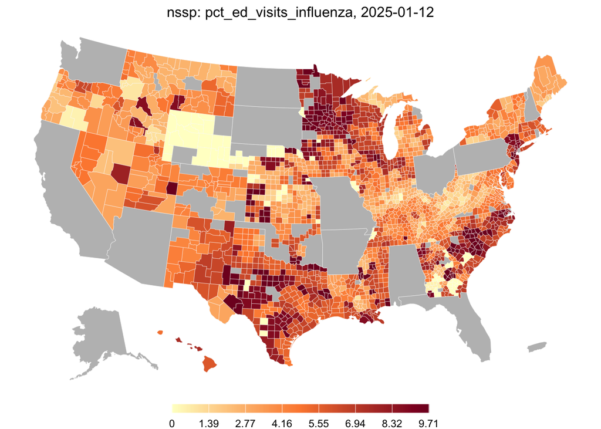

```r
plot(nssp_county, time_value = "2025-01-12")
```

The following code uses the `epidatr` package to return county-level data, where `geo_value` is the FIPS code of the county. Again, the values returned for an individual county are really those of the parent HSA.

```r
epidatr::pub_covidcast(source = "nssp", signals = "pct_ed_visits_influenza", geo_type = "county", geo_values = "25015", time_type = "week")
```

```
# A tibble: 154 × 15
   geo_value signal    source geo_type time_type time_value direction issue
   <chr>     <chr>     <chr>  <fct>    <fct>     <date>         <dbl> <date>
 1 25015     pct_ed_v… nssp   county   week      2022-09-25        NA 2025-09-07
 2 25015     pct_ed_v… nssp   county   week      2022-10-02        NA 2025-09-07
 3 25015     pct_ed_v… nssp   county   week      2022-10-09        NA 2025-09-07
 4 25015     pct_ed_v… nssp   county   week      2022-10-16        NA 2025-09-07
 5 25015     pct_ed_v… nssp   county   week      2022-10-23        NA 2025-09-07
 6 25015     pct_ed_v… nssp   county   week      2022-10-30        NA 2025-09-07
 7 25015     pct_ed_v… nssp   county   week      2022-11-06        NA 2025-09-07
 8 25015     pct_ed_v… nssp   county   week      2022-11-13        NA 2025-09-07
 9 25015     pct_ed_v… nssp   county   week      2022-11-20        NA 2025-09-07
10 25015     pct_ed_v… nssp   county   week      2022-11-27        NA 2025-09-07
# ℹ 144 more rows
# ℹ 7 more variables: lag <dbl>, missing_value <dbl>, missing_stderr <dbl>,
#   missing_sample_size <dbl>, value <dbl>, stderr <dbl>, sample_size <dbl>
```

## Why use NSSP HSA data?

Metro-level disease trends and forecasts may differ markedly from state and national trends. Building the capacity to forecast at the metro-level may be crucial in times of outbreak planning and response.

NSSP HSA-level data are **publicly available**, making it quicker and easier to expand forecasting efforts to additional jurisdictions that report these data.

## Colorado

### Trends

Trends

### HSA Map

HSA Map

### HSAs

HSAs

## Connecticut

### Trends

Trends

### HSA Map

HSA Map

### HSAs

HSAs)

## Delaware

### Trends

Trends

### HSA Map

HSA Map

### HSAs

HSAs

## District of Columbia

### Trends

Trends

### HSA Map

HSA Map

### HSAs

HSAs

## Georgia

### Trends

Trends 1 Trends 2 Trends 3

### HSA Map

HSA Map

### HSAs

HSAs 1 HSAs 2

## Hawaii

### Trends

Trends

### HSA Map

HSA Map

### HSAs

HSAs

## Idaho

### Trends

Trends

### HSA Map

HSA Map

### HSAs

HSAs

## Illinois

### Trends

Trends 1 Trends 2 Trends 3

### HSA Map

HSA Map

### HSAs

HSAs 1 HSAs 2

## Indiana

### Trends

Trends 1 Trends 2 Trends 3

### HSA Map

HSA Map

### HSAs

HSAs

## Iowa

### Trends

Trends 1 Trends 2 Trends 3

### HSA Map

HSA Map

### HSAs

HSAs 1 HSAs 2

## Kansas

### Trends

Trends 1 Trends 2 Trends 3

### HSA Map

HSA Map

### HSAs

HSAs 1 HSAs 2

## Kentucky

### Trends

Trends 1 Trends 2 Trends 3

### HSA Map

HSA Map

### HSAs

HSAs

## Louisiana

### Trends

Trends 1 Trends 2

### HSA Map

HSA Map

### HSAs

HSAs

## Maine

### Trends

Trends

### HSA Map

HSA Map

### HSAs

HSAs

## Maryland

### Trends

Trends

### HSA Map

HSA Map

### HSAs

HSAs

## Massachusetts

### Trends

Trends

### HSA Map

HSA Map

### HSAs

HSAs

## Michigan

### Trends

Trends 1 Trends 2

### HSA Map

HSA Map

### HSAs

HSAs

## Minnesota

### Trends

Trends 1 Trends 2

### HSA Map

HSA Map

### HSAs

HSAs

## Mississippi

### Trends

Trends 1 Trends 2

### HSA Map

HSA Map

### HSAs

HSAs HSAs

## Montana

### Trends

Trends 1 Trends 2

### HSA Map

HSA Map

### HSAs

HSAs

## Nebraska

### Trends

Trends 1 Trends 2

### HSA Map

HSA Map

### HSAs

HSAs

## Nevada

### Trends

Trends

### HSA Map

HSA Map

### HSAs

HSAs

## New Jersey

### Trends

Trends

### HSA Map

HSA Map

### HSAs

HSAs

## New Mexico

### Trends

Trends

### HSA Map

HSA Map

### HSAs

HSAs

## New York

### Trends

Trends 1 Trends 2

### HSA Map

HSA Map

### HSAs

HSAs

## North Carolina

### Trends

Trends 1 Trends 2 Trends 3

### HSA Map

HSA Map

### HSAs

HSAs

## Oklahoma

### Trends

Trends

### HSA Map

HSA Map

### HSAs

HSAs

## Oregon

### Trends

Trends 1 Trends 2

### HSA Map

HSA Map

## South Carolina

### Trends

Trends 1 Trends 2

### HSA Map

HSA Map

### HSAs

HSAs

## Tennessee

### Trends

Trends 1 Trends 2 Trends 3

### HSA Map

HSA Map

### HSAs

HSAs

## Texas

### Trends

Trends 1 Trends 2 Trends 3 Trends 4 Trends 5

### HSA Map

HSA Map

### HSAs

HSAs 1 HSAs 2

## Utah

### Trends

Trends

### HSA Map

HSA Map

### HSAs

HSAs

## Vermont

### Trends

Trends

### HSA Map

HSA Map

### HSAs

HSAs

## Virgina

### Trends

Trends 1 Trends 2

### HSA Map

HSA Map

### HSAs

HSAs

## West Virginia

### Trends

Trends 1 Trends 2

### HSA Map

HSA Map

### HSAs

HSAs

## Wisconsin

### Trends

Trends 1 Trends 2 Trends 3

### HSA Map

HSA Map

### HSAs

HSAs

## Wyoming

### Trends

Trends

### HSA Map

HSA Map

### HSAs

HSAs